# Master Project

## 4.3 Odds ratio plot

Odds ratio plot we agreed to add after presentation (Gao originally responsible for implementing)

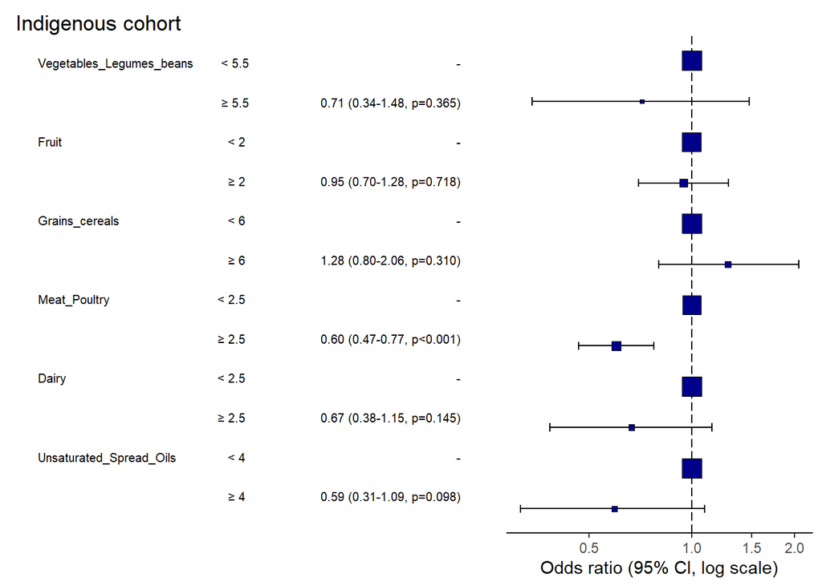

```r
# Indigenous
explanatory_food <- c( "Vegetables_Legumes_beans",'Fruit','Grains_cereals','Meat_Poultry','Dairy','Unsaturated_Spread_Oils')
explanatory_nutr <- c( 'FreeSugar','TotalFat','Carbohydrates','Protein','SaturatedTransFat','DietaryFibre')
dependent <- "cvd_risk_stat"

#Indigenous cohort

p1 = cvdnutrdf %>% filter(group == 'Indigenous') %>% or_plot(dependent, explanatory_food,table_text_size = 2.6, dependent_label = "Indigenous cohort", suffix = "")
```

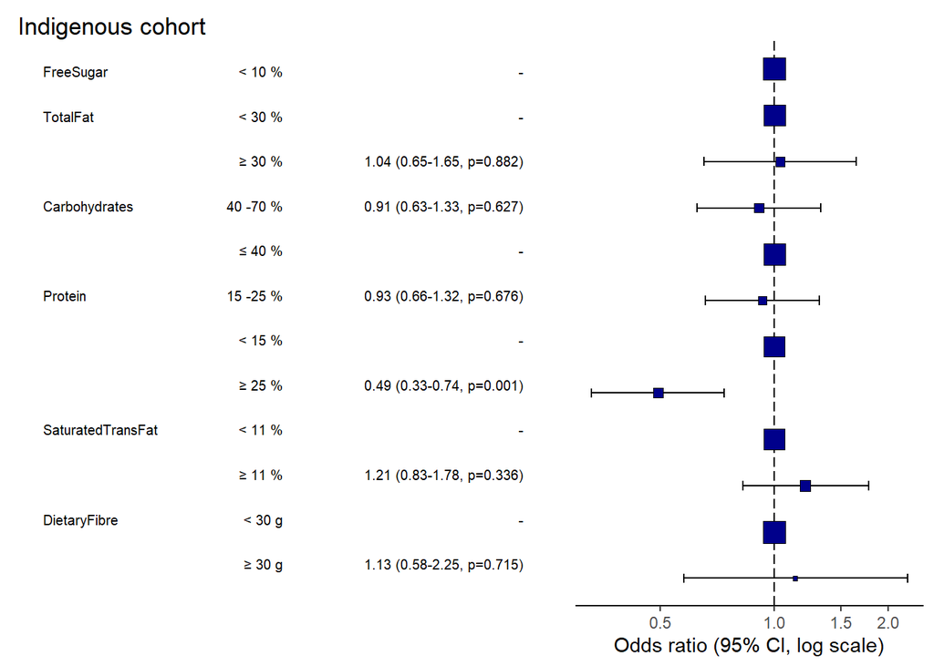

```r
p2 = cvdnutrdf %>% filter(group == 'Indigenous') %>% or_plot(dependent, explanatory_nutr,table_text_size = 2.6, dependent_label = "Indigenous cohort", suffix = "")
```

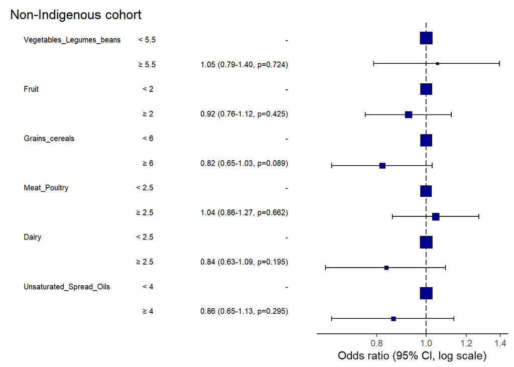

```r
# Non-Indigenous)
p3 = cvdnutrdf %>% filter(group == 'Non-Indigenous') %>% or_plot(dependent, explanatory_food,table_text_size = 2.6, dependent_label = "Non-Indigenous cohort", suffix = "")
```

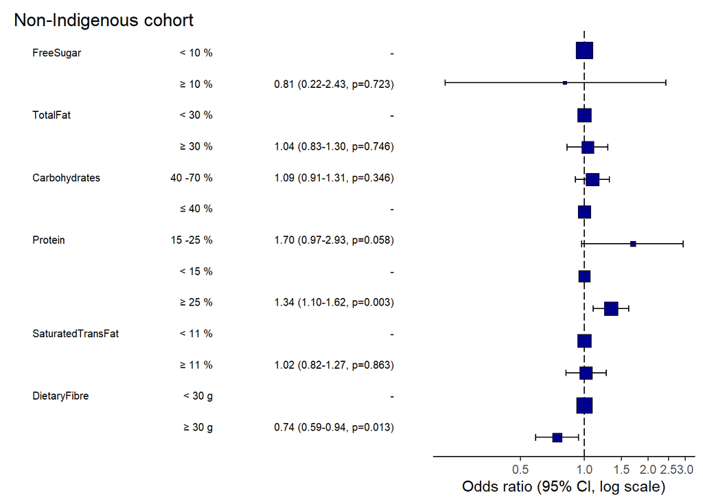

```r
p4 = cvdnutrdf %>% filter(group == 'Non-Indigenous') %>% or_plot(dependent, explanatory_nutr,table_text_size = 2.6, dependent_label = "Non-Indigenous cohort", suffix = "")
```

## Findings # Odds Plot

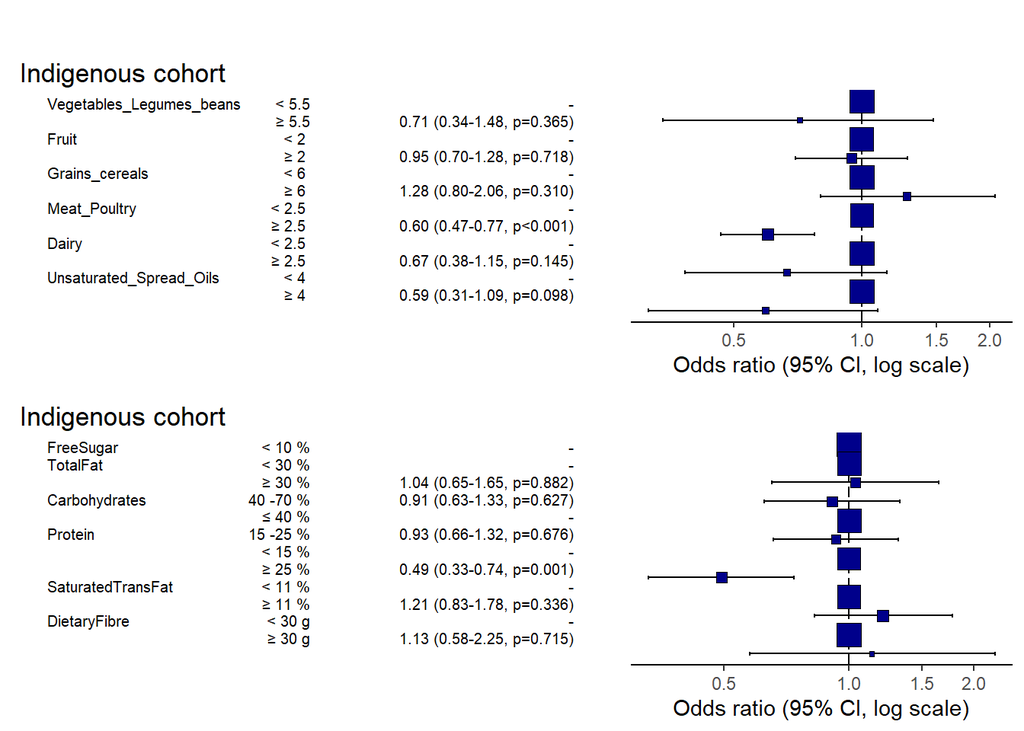

```r
p51 = grid.arrange(p1, p2, ncol = 1, top = textGrob('', gp = gpar(fontsize = 20)))
```

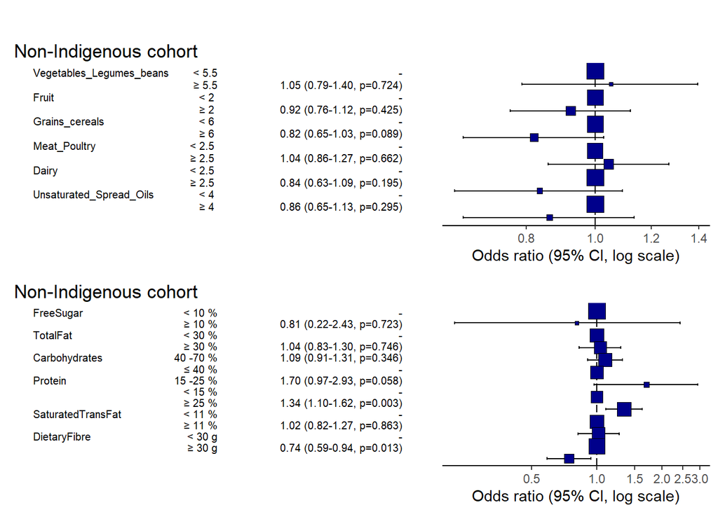

```r
p6 = grid.arrange(p3, p4, ncol = 1, top = textGrob('', gp = gpar(fontsize = 20)))
```

```r
p51
```

```r
p6
```

NonInd cohot:  
Diet with high intake of Protein (>= 25%)corresponds to 1.34 on OR plot (p < 0.05)  
Diet with hight intake of Dietary fibre (>= 30g) corresponds to 0.74 on OR plot (p < 0.05)  
# Future direction Build regression model with these vars / some sort of classification model?  
interaction effect? feedback greatly appreciated.  
(to be continued…)

```r
model_interaction <- glm(cvd_risk_stat ~ (Vegetables_Legumes_beans + Fruit + Grains_cereals + Meat_Poultry + Dairy + Unsaturated_Spread_Oils + FreeSugar + TotalFat + Carbohydrates + Protein + SaturatedTransFat + DietaryFibre) * group, data = cvdnutrdf, family = binomial, na.action = na.exclude)
summary(model_interaction)
```

```
##
## Call:
## glm(formula = cvd_risk_stat ~ (Vegetables_Legumes_beans + Fruit +
##     Grains_cereals + Meat_Poultry + Dairy + Unsaturated_Spread_Oils +
##     FreeSugar + TotalFat + Carbohydrates + Protein + SaturatedTransFat +
##     DietaryFibre) * group, family = binomial, data = cvdnutrdf,
##     na.action = na.exclude)
##
## Coefficients:
##                                                    Estimate Std. Error z value
## (Intercept)                                         0.36141    0.04866   7.427
## Vegetables_Legumes_beans≥ 5.5                      -0.22814    0.40664  -0.561
## Fruit≥ 2                                           -0.01066    0.16114  -0.066
## Grains_cereals≥ 6                                   0.36863    0.25904   1.423
## Meat_Poultry≥ 2.5                                  -0.62795    0.15103  -4.158
## Dairy≥ 2.5                                         -0.22014    0.29123  -0.756
## Unsaturated_Spread_Oils≥ 4                         -0.58653    0.33459  -1.753
## FreeSugar≥ 10 %                                   -11.31355  324.74399  -0.035
## TotalFat≥ 30 %                                      0.18498    0.24169   0.765
## Carbohydrates≥ 70 %                                11.83603  324.74380   0.036
## Carbohydrates40 -70 %                              -0.25951    0.19914  -1.303
## Protein≥ 25 %                                      -0.57380    0.21123  -2.716
## Protein15 -25 %                                     0.10000    0.18378   0.544
## SaturatedTransFat≥ 11 %                             0.20953    0.19817   1.057
## DietaryFibre≥ 30 g                                  0.21413    0.38991   0.549
## groupNon-Indigenous                                -1.21929    0.09816 -12.422
## Vegetables_Legumes_beans≥ 5.5:groupNon-Indigenous   0.34105    0.43626   0.782
## Fruit≥ 2 :groupNon-Indigenous                      -0.05986    0.19327  -0.310
## Grains_cereals≥ 6 :groupNon-Indigenous             -0.54727    0.28794  -1.901
## Meat_Poultry≥ 2.5 :groupNon-Indigenous              0.57117    0.18609   3.069
## Dairy≥ 2.5 :groupNon-Indigenous                    -0.02372    0.32451  -0.073
## Unsaturated_Spread_Oils≥ 4 :groupNon-Indigenous     0.48799    0.36632   1.332
## FreeSugar≥ 10 %:groupNon-Indigenous                11.25290  324.74456   0.035
## TotalFat≥ 30 %:groupNon-Indigenous                 -0.13951    0.26830  -0.520
## Carbohydrates≥ 70 %:groupNon-Indigenous             1.58792  459.25702   0.003
## Carbohydrates40 -70 %:groupNon-Indigenous           0.36945    0.22224   1.662
## Protein≥ 25 %:groupNon-Indigenous                   0.89529    0.23591   3.795
## Protein15 -25 %:groupNon-Indigenous                 0.41964    0.33702   1.245
## SaturatedTransFat≥ 11 %:groupNon-Indigenous        -0.17082    0.22904  -0.746
## DietaryFibre≥ 30 g:groupNon-Indigenous             -0.41533    0.41554  -0.999
```

[output cut: 27 more lines]

```
## Protein≥ 25 %:groupNon-Indigenous                 0.000148 ***
## Protein15 -25 %:groupNon-Indigenous               0.213071
## SaturatedTransFat≥ 11 %:groupNon-Indigenous       0.455772
## DietaryFibre≥ 30 g:groupNon-Indigenous            0.317556
## ---
## Signif. codes:  0 '***' 0.001 '**' 0.01 '*' 0.05 '.' 0.1 ' ' 1
##
## (Dispersion parameter for binomial family taken to be 1)
##
##     Null deviance: 6739.7  on 4898  degrees of freedom
## Residual deviance: 6395.2  on 4869  degrees of freedom
##   (101 observations deleted due to missingness)
## AIC: 6455.2
##
## Number of Fisher Scoring iterations: 11
```

```r
# Use stepwise for a 'quick' best model:
stepwise_model <- MASS::stepAIC(model_interaction, direction = "both", trace = FALSE)
summary(stepwise_model)
```

```
##
## Call:
## glm(formula = cvd_risk_stat ~ Grains_cereals + Meat_Poultry +
##     Dairy + Unsaturated_Spread_Oils + Protein + group + Grains_cereals:group +
##     Meat_Poultry:group + Protein:group, family = binomial, data = cvdnutrdf,
##     na.action = na.exclude)
##
## Coefficients:
##                                        Estimate Std. Error z value Pr(>|z|)
## (Intercept)                             0.36526    0.04628   7.892 2.97e-15 ***
## Grains_cereals≥ 6                       0.36688    0.24424   1.502 0.133067
## Meat_Poultry≥ 2.5                      -0.63652    0.14717  -4.325 1.52e-05 ***
## Dairy≥ 2.5                             -0.23658    0.12586  -1.880 0.060154 .
## Unsaturated_Spread_Oils≥ 4             -0.20289    0.12928  -1.569 0.116567
## Protein≥ 25 %                          -0.47211    0.14334  -3.294 0.000989 ***
## Protein15 -25 %                         0.09699    0.18280   0.531 0.595705
## groupNon-Indigenous                    -1.17839    0.08658 -13.611  < 2e-16 ***
## Grains_cereals≥ 6 :groupNon-Indigenous -0.56709    0.27032  -2.098 0.035916 *
## Meat_Poultry≥ 2.5 :groupNon-Indigenous  0.56150    0.17850   3.146 0.001657 **
## Protein≥ 25 %:groupNon-Indigenous       0.84499    0.17125   4.934 8.05e-07 ***
## Protein15 -25 %:groupNon-Indigenous     0.43917    0.33399   1.315 0.188534
## ---
## Signif. codes:  0 '***' 0.001 '**' 0.01 '*' 0.05 '.' 0.1 ' ' 1
##
## (Dispersion parameter for binomial family taken to be 1)
##
##     Null deviance: 6739.7  on 4898  degrees of freedom
## Residual deviance: 6409.5  on 4887  degrees of freedom
##   (101 observations deleted due to missingness)
## AIC: 6433.5
##
## Number of Fisher Scoring iterations: 4
```